# Bellabeat Data Analysis Case Study

Tanvir Ahmed Shanto

2025-12-25

## Load Packages

```r
library(tidyverse)
library(lubridate)
library(patchwork)
```

## Load Dataset

The dataset used in this case study can be found [here](https://www.kaggle.com/datasets/arashnic/fitbit)

```r
daily_activity <- read.csv("dailyActivity_merged.csv")

hourly_steps <- read.csv("hourlySteps_merged.csv")
```

## Inspect Dataset

Lets find out if there are any duplicate or null values

```r
# View the Top 5 Rows of daily_activity
head(daily_activity)
```

```
##           Id ActivityDate TotalSteps TotalDistance TrackerDistance
## 1 1503960366    4/12/2016      13162          8.50            8.50
## 2 1503960366    4/13/2016      10735          6.97            6.97
## 3 1503960366    4/14/2016      10460          6.74            6.74
## 4 1503960366    4/15/2016       9762          6.28            6.28
## 5 1503960366    4/16/2016      12669          8.16            8.16
## 6 1503960366    4/17/2016       9705          6.48            6.48
##   LoggedActivitiesDistance VeryActiveDistance ModeratelyActiveDistance
## 1                        0               1.88                     0.55
## 2                        0               1.57                     0.69
## 3                        0               2.44                     0.40
## 4                        0               2.14                     1.26
## 5                        0               2.71                     0.41
## 6                        0               3.19                     0.78
##   LightActiveDistance SedentaryActiveDistance VeryActiveMinutes
## 1                6.06                       0                25
## 2                4.71                       0                21
## 3                3.91                       0                30
## 4                2.83                       0                29
## 5                5.04                       0                36
## 6                2.51                       0                38
##   FairlyActiveMinutes LightlyActiveMinutes SedentaryMinutes Calories
## 1                  13                  328              728     1985
## 2                  19                  217              776     1797
## 3                  11                  181             1218     1776
## 4                  34                  209              726     1745
## 5                  10                  221              773     1863
## 6                  20                  164              539     1728
```

```r
# Identify all the columns is daily_activity
colnames(daily_activity)
```

```
##  [1] "Id"                       "ActivityDate"
##  [3] "TotalSteps"               "TotalDistance"
##  [5] "TrackerDistance"          "LoggedActivitiesDistance"
##  [7] "VeryActiveDistance"       "ModeratelyActiveDistance"
##  [9] "LightActiveDistance"      "SedentaryActiveDistance"
## [11] "VeryActiveMinutes"        "FairlyActiveMinutes"
## [13] "LightlyActiveMinutes"     "SedentaryMinutes"
## [15] "Calories"
```

```r
# Check for duplicates
sum(duplicated(daily_activity))
```

```
## [1] 0
```

```r
# Hourly Steps

head(hourly_steps)
```

```
##           Id          ActivityHour StepTotal
## 1 1503960366 4/12/2016 12:00:00 AM       373
## 2 1503960366  4/12/2016 1:00:00 AM       160
## 3 1503960366  4/12/2016 2:00:00 AM       151
## 4 1503960366  4/12/2016 3:00:00 AM         0
## 5 1503960366  4/12/2016 4:00:00 AM         0
## 6 1503960366  4/12/2016 5:00:00 AM         0
```

```r
sum(duplicated(hourly_steps))
```

```
## [1] 0
```

## Clean Datasets

Drop the null(N/A) and duplicate values

```r
# daily_activity - Select distinct records and drop records will null values
daily_activity_clean <- daily_activity %>% distinct() %>% drop_na();

summary(daily_activity_clean);
```

```
##        Id            ActivityDate         TotalSteps    TotalDistance
##  Min.   :1.504e+09   Length:940         Min.   :    0   Min.   : 0.000
##  1st Qu.:2.320e+09   Class :character   1st Qu.: 3790   1st Qu.: 2.620
##  Median :4.445e+09   Mode  :character   Median : 7406   Median : 5.245
##  Mean   :4.855e+09                      Mean   : 7638   Mean   : 5.490
##  3rd Qu.:6.962e+09                      3rd Qu.:10727   3rd Qu.: 7.713
##  Max.   :8.878e+09                      Max.   :36019   Max.   :28.030
##  TrackerDistance  LoggedActivitiesDistance VeryActiveDistance
##  Min.   : 0.000   Min.   :0.0000           Min.   : 0.000
##  1st Qu.: 2.620   1st Qu.:0.0000           1st Qu.: 0.000
##  Median : 5.245   Median :0.0000           Median : 0.210
##  Mean   : 5.475   Mean   :0.1082           Mean   : 1.503
##  3rd Qu.: 7.710   3rd Qu.:0.0000           3rd Qu.: 2.052
##  Max.   :28.030   Max.   :4.9421           Max.   :21.920
##  ModeratelyActiveDistance LightActiveDistance SedentaryActiveDistance
##  Min.   :0.0000           Min.   : 0.000      Min.   :0.000000
##  1st Qu.:0.0000           1st Qu.: 1.945      1st Qu.:0.000000
##  Median :0.2400           Median : 3.365      Median :0.000000
##  Mean   :0.5675           Mean   : 3.341      Mean   :0.001606
##  3rd Qu.:0.8000           3rd Qu.: 4.783      3rd Qu.:0.000000
##  Max.   :6.4800           Max.   :10.710      Max.   :0.110000
##  VeryActiveMinutes FairlyActiveMinutes LightlyActiveMinutes SedentaryMinutes
##  Min.   :  0.00    Min.   :  0.00      Min.   :  0.0        Min.   :   0.0
##  1st Qu.:  0.00    1st Qu.:  0.00      1st Qu.:127.0        1st Qu.: 729.8
##  Median :  4.00    Median :  6.00      Median :199.0        Median :1057.5
##  Mean   : 21.16    Mean   : 13.56      Mean   :192.8        Mean   : 991.2
##  3rd Qu.: 32.00    3rd Qu.: 19.00      3rd Qu.:264.0        3rd Qu.:1229.5
##  Max.   :210.00    Max.   :143.00      Max.   :518.0        Max.   :1440.0
##     Calories
##  Min.   :   0
##  1st Qu.:1828
##  Median :2134
##  Mean   :2304
##  3rd Qu.:2793
##  Max.   :4900
```

```r
# hourly_steps
hourly_steps_clean <- hourly_steps %>% distinct() %>% drop_na();

# Convert Activity hour to a proper format
# The 'mdy_hms' function from lubridate handles the "Month/Day/Year Hour:Min:Sec AM/PM" format
hourly_steps_clean$ActivityHour <- mdy_hms(hourly_steps_clean$ActivityHour)

# Verify if data type has changed to a Date format
class(hourly_steps_clean$ActivityHour)
```

```
## [1] "POSIXct" "POSIXt"
```

```r
summary(hourly_steps_clean)
```

```
##        Id             ActivityHour                   StepTotal
##  Min.   :1.504e+09   Min.   :2016-04-12 00:00:00   Min.   :    0.0
##  1st Qu.:2.320e+09   1st Qu.:2016-04-19 01:00:00   1st Qu.:    0.0
##  Median :4.445e+09   Median :2016-04-26 06:00:00   Median :   40.0
##  Mean   :4.848e+09   Mean   :2016-04-26 11:46:42   Mean   :  320.2
##  3rd Qu.:6.962e+09   3rd Qu.:2016-05-03 19:00:00   3rd Qu.:  357.0
##  Max.   :8.878e+09   Max.   :2016-05-12 15:00:00   Max.   :10554.0
```

### Key Insights

A few noticeable findings are listed below:

- On average the users are very active for 21.16 minutes
- The users are sedentary for 991 minutes or, 16.5 hours a day

## Correlation between total steps and calories

This analysis examines the relationship between total daily steps and calories burned. A scatterplot is used to assess whether higher step counts are associated with increased daily energy expenditure.

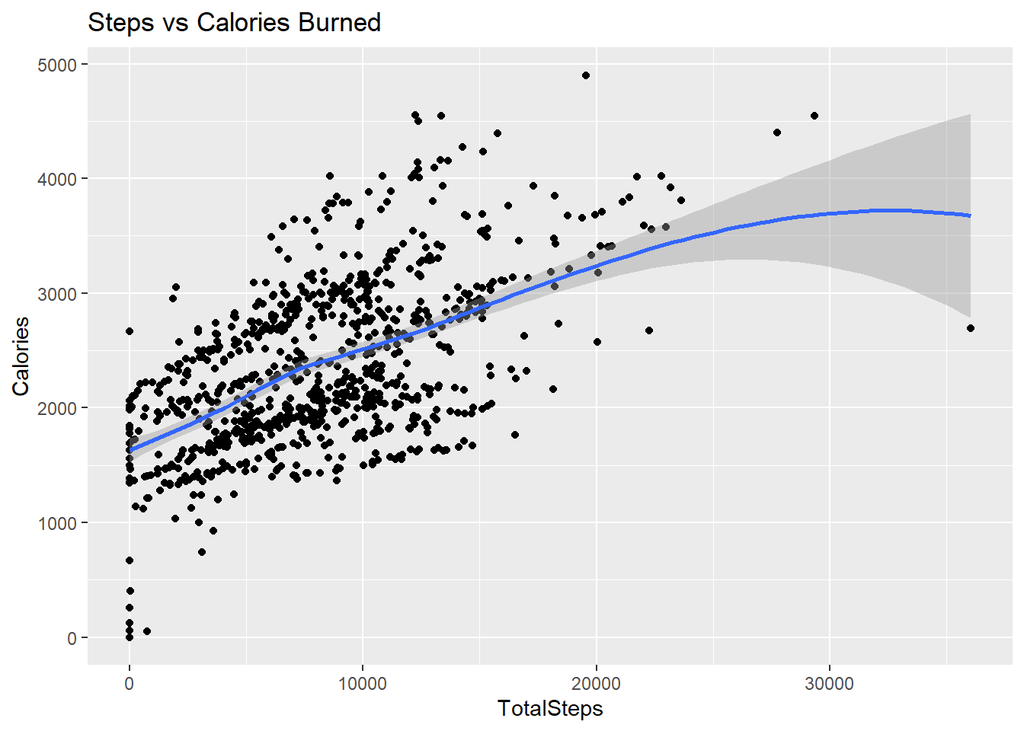

```r
ggplot(data = daily_activity_clean, aes(x=TotalSteps, y=Calories)) + geom_point() + geom_smooth() + labs(title = "Steps vs Calories Burned")
```

## When Users Take Most Steps in a Day

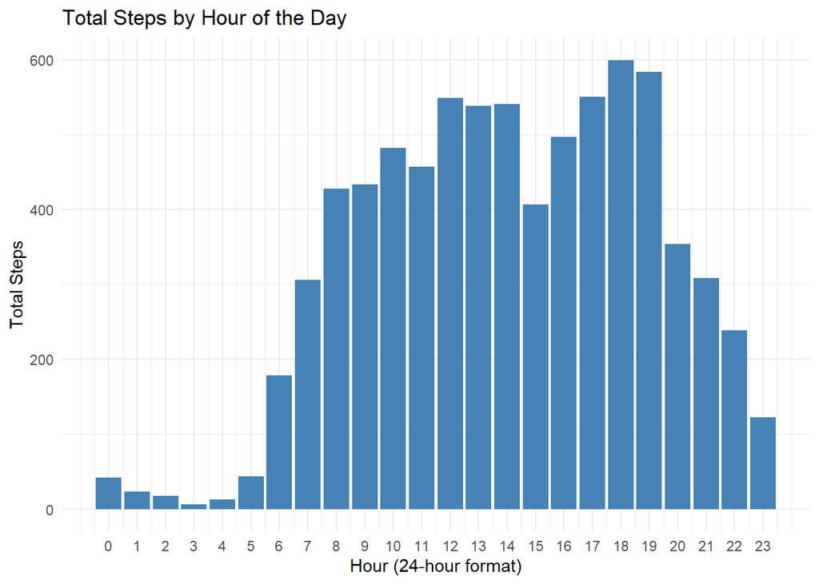

```r
# Extract the hour (this will give you values from 0 to 23)
hourly_steps_clean$Hour <- hour(hourly_steps_clean$ActivityHour)

# Calculate the total steps for each hour
hourly_summary <- hourly_steps_clean %>%
  group_by(Hour) %>%
  summarize(TotalSteps = mean(StepTotal))

# Create the bar graph
ggplot(hourly_summary, aes(x = Hour, y = TotalSteps)) +
  geom_bar(stat = "identity", fill = "steelblue") +
  scale_x_continuous(breaks = 0:23) + # Ensure all hours are labeled
  labs(
    title = "Total Steps by Hour of the Day",
    x = "Hour (24-hour format)",
    y = "Total Steps"
  ) +
  theme_minimal()
```

### Key Insights

From the chart it is evident that the users walk the most from 6pm to 7pm. Most probably the users leave work and walk to home or go the gym for excercise at that time.

## Impact of Activity Intensity on Calories Burned

To understand how different activity intensity levels relate to calorie expenditure, I examined the relationship between calories burned and three activity categories: very active, fairly active, and lightly active minutes. Scatterplots were used to compare each activity level with daily calories burned and identify overall patterns.

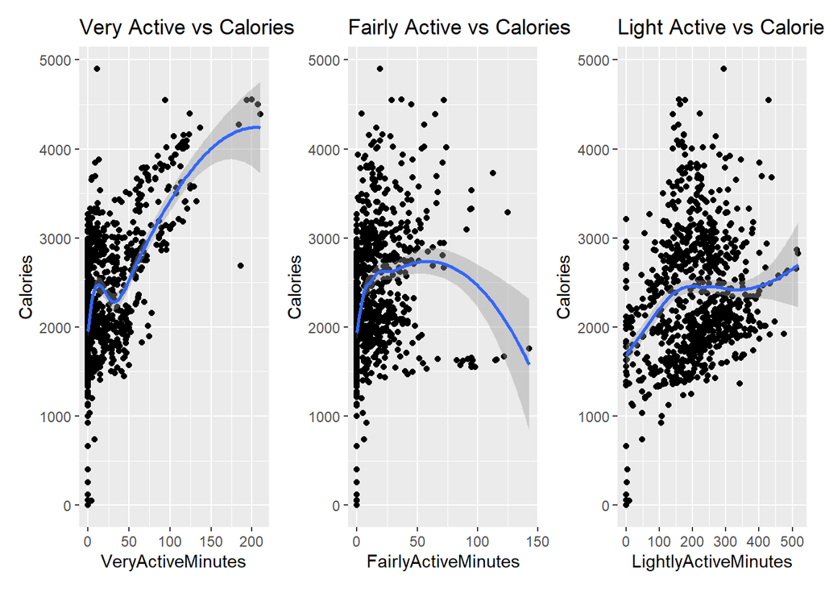

```r
plot1 <- ggplot(data = daily_activity_clean, aes(x=VeryActiveMinutes, y=Calories)) + geom_point() + geom_smooth() + labs(title = "Very Active vs Calories")

plot2 <- ggplot(data = daily_activity_clean, aes(x=FairlyActiveMinutes, y=Calories)) + geom_point() + geom_smooth() + labs(title = "Fairly Active vs Calories")

plot3 <- ggplot(data = daily_activity_clean, aes(x=LightlyActiveMinutes, y=Calories)) + geom_point() + geom_smooth() + labs(title = "Light Active vs Calories")

# Combine all 3 plots into a single one

plot1 + plot2 + plot3
```

From the Plots it seems, Calories burned have strong Correlation with VeryActiveMinutes. While the other two have showcased weak correlation.

Lets analyze this further using Pearson correlation matrix

```r
daily_activity_clean %>%
  select(Calories, VeryActiveMinutes, FairlyActiveMinutes, LightlyActiveMinutes) %>%
  cor(use = "complete.obs")
```

```
##                       Calories VeryActiveMinutes FairlyActiveMinutes
## Calories             1.0000000        0.61583827           0.2976235
## VeryActiveMinutes    0.6158383        1.00000000           0.3124204
## FairlyActiveMinutes  0.2976235        0.31242035           1.0000000
## LightlyActiveMinutes 0.2867175        0.05192591           0.1488199
##                      LightlyActiveMinutes
## Calories                       0.28671753
## VeryActiveMinutes              0.05192591
## FairlyActiveMinutes            0.14881991
## LightlyActiveMinutes           1.00000000
```

## Final Recommendations

- Encourage users to increase daily step counts through personalized goals and reminders.
- Introduce features that promote breaking up long sedentary periods.
- Use activity consistency metrics to identify low-engagement users and target them with motivational notifications.
- Improve user education around device usage to reduce missing or zero activity data.

## Limitations

- The dataset represents a limited time period and sample size.
- Some activity variables contain missing or zero values, which may impact correlation strength.
- Results should be validated using a larger and more recent dataset.